# Module 11 Exercise

Joe Martin

10/31/2021

Create model linear regression model. Train and test sets will have a 70/30 split. In this section, create the cross-fold validation object. 5 folds repeated 5 times. Data sets for split and folds will be stratified on BodyTemp variable.

```r
set.seed(123)

# Set up for Linear Regression
df_split <- initial_split(df, strata = BodyTemp, prop=7/10)

training_df <- training(df_split)
testing_df <- testing(df_split)

#Set up for cross-fold validation
folds <- vfold_cv(training_df, v = 5, repeats = 5, strata = BodyTemp)

# create recipe
bt_train_rec <- recipe(BodyTemp ~ ., data = training_df) %>%
  step_dummy(all_nominal_predictors())

# Use step_dummy to transform categorical variables into dummy variables

lm_mod <- linear_reg() %>%
  set_engine("lm")

bt_workflow <-
  workflow() %>%
  add_model(lm_mod) %>%
  add_recipe(bt_train_rec)

bt_fit <- bt_workflow %>%
  fit(training_df)

bt_fit %>%
  extract_fit_parsnip() %>%
  tidy()
```

```
## # A tibble: 32 x 5
##    term                  estimate std.error statistic   p.value
##    <chr>                    <dbl>     <dbl>     <dbl>     <dbl>
##  1 (Intercept)            98.0        0.387   253.    0
##  2 SwollenLymphNodes_Yes  -0.140      0.112    -1.25  0.211
##  3 ChestCongestion_Yes     0.193      0.116     1.66  0.0972
##  4 ChillsSweats_Yes        0.185      0.155     1.19  0.234
##  5 NasalCongestion_Yes    -0.275      0.137    -2.00  0.0456
##  6 Sneeze_Yes             -0.469      0.118    -3.96  0.0000855
##  7 Fatigue_Yes             0.278      0.204     1.37  0.173
##  8 SubjectiveFever_Yes     0.483      0.123     3.92  0.000103
##  9 Headache_Yes           -0.0169     0.150    -0.112 0.911
## 10 Weakness_Mild           0.0697     0.234     0.298 0.766
## # ... with 22 more rows
```

Evaluate model performance

```r
# Check the model performance

predict(bt_fit, testing_df)
```

```
## # A tibble: 222 x 1
##    .pred
##    <dbl>
##  1  99.3
##  2  99.0
##  3  99.8
##  4  99.8
##  5  98.8
##  6  99.2
##  7  99.7
##  8  99.6
##  9  99.5
## 10  99.4
## # ... with 212 more rows
```

```r
bt_aug_train <- augment(bt_fit, training_df)
bt_aug_train %>% select(BodyTemp, .pred)
```

```
## # A tibble: 508 x 2
##    BodyTemp .pred
##       <dbl> <dbl>
##  1     97.8  98.8
##  2     98.1  98.5
##  3     98.1  98.6
##  4     98.2  98.6
##  5     97.8  99.0
##  6     98.2  98.4
##  7     98.1  98.1
##  8     98    99.5
##  9     97.7  98.8
## 10     98.2  99.1
## # ... with 498 more rows
```

```r
bt_aug_test <- augment(bt_fit,testing_df)
bt_aug_test %>% select(BodyTemp, .pred)
```

```
## # A tibble: 222 x 2
##    BodyTemp .pred
##       <dbl> <dbl>
##  1    100.   99.3
##  2     98.8  99.0
##  3     98.2  99.8
##  4     97.9  99.8
##  5    102.   98.8
##  6     99.3  99.2
##  7     97.8  99.7
##  8     99.5  99.6
##  9     99.7  99.5
## 10     98.8  99.4
## # ... with 212 more rows
```

```r
bt_error_train <- bt_aug_train %>%
  rmse(truth = BodyTemp, .pred)
bt_error_train$model <- "BodyTemp Training"
bt_error_test <- bt_aug_test %>%
  rmse(truth = BodyTemp, .pred)
bt_error_test$model <- "BodyTemp Test"
bt_error_rmse <- bind_rows(bt_error_train, bt_error_test)
bt_error_rmse
```

```
## # A tibble: 2 x 4
##   .metric .estimator .estimate model
##   <chr>   <chr>          <dbl> <chr>
## 1 rmse    standard        1.10 BodyTemp Training
## 2 rmse    standard        1.20 BodyTemp Test
```

Create a null model to compare the linear regression model.

```r
# Create a null model
null_rec <- recipe(BodyTemp ~ 1, data = training_df) %>%
  step_dummy(all_nominal_predictors())

null_wf <-
  workflow() %>%
  add_model(lm_mod) %>%
  add_recipe(null_rec)

null_fit <- null_wf %>%
  fit(training_df)

null_fit %>%
  extract_fit_parsnip() %>%
  tidy()
```

```
## # A tibble: 1 x 5
##   term        estimate std.error statistic p.value
##   <chr>          <dbl>     <dbl>     <dbl>   <dbl>
## 1 (Intercept)     98.9    0.0537     1842.       0
```

Evaluate model performance.

```r
# Check Null Model performance
predict(null_fit, testing_df)
```

```
## # A tibble: 222 x 1
##    .pred
##    <dbl>
##  1  98.9
##  2  98.9
##  3  98.9
##  4  98.9
##  5  98.9
##  6  98.9
##  7  98.9
##  8  98.9
##  9  98.9
## 10  98.9
## # ... with 212 more rows
```

```r
null_aug_train <- augment(null_fit, training_df)
null_aug_train %>% select(BodyTemp, .pred)
```

```
## # A tibble: 508 x 2
##    BodyTemp .pred
##       <dbl> <dbl>
##  1     97.8  98.9
##  2     98.1  98.9
##  3     98.1  98.9
##  4     98.2  98.9
##  5     97.8  98.9
##  6     98.2  98.9
##  7     98.1  98.9
##  8     98    98.9
##  9     97.7  98.9
## 10     98.2  98.9
## # ... with 498 more rows
```

```r
null_aug_test <- augment(null_fit,testing_df)
null_aug_test %>% select(BodyTemp, .pred)
```

```
## # A tibble: 222 x 2
##    BodyTemp .pred
##       <dbl> <dbl>
##  1    100.   98.9
##  2     98.8  98.9
##  3     98.2  98.9
##  4     97.9  98.9
##  5    102.   98.9
##  6     99.3  98.9
##  7     97.8  98.9
##  8     99.5  98.9
##  9     99.7  98.9
## 10     98.8  98.9
## # ... with 212 more rows
```

```r
null_error_train <- null_aug_train %>%
  rmse(truth = BodyTemp, .pred)
null_error_train$model <- "Null Training Model"


null_error_test <- null_aug_test %>%
  rmse(truth = BodyTemp, .pred)
null_error_test$model <- "Null Testing Model"

null_error_rmse <- bind_rows(null_error_train,null_error_test)
null_error_rmse
```

```
## # A tibble: 2 x 4
##   .metric .estimator .estimate model
##   <chr>   <chr>          <dbl> <chr>
## 1 rmse    standard        1.21 Null Training Model
## 2 rmse    standard        1.16 Null Testing Model
```

Create a decision tree. Use the same data sets for training and the same cross-fold validation object.

```r
# decision tree
# continue using training_df and testing_df for data sets

tune_spec <- decision_tree(
  cost_complexity = tune(),
  tree_depth = tune()
  ) %>%
  set_engine("rpart") %>%
  set_mode("regression")

tree_grid <- grid_regular(cost_complexity(),
                          tree_depth(),
                          levels = 5)

# create tree workflow with bodytemp train recipe
tree_wf <- workflow() %>%
  add_model(tune_spec) %>%
  add_recipe(bt_train_rec)

# create tree with new workflow
tree_res <- tree_wf %>%
  tune_grid(
    resamples = folds,
    grid = tree_grid
  )

tree_res %>%
  collect_metrics()
```

```
## # A tibble: 50 x 8
##    cost_complexity tree_depth .metric .estimator     mean     n  std_err .config
##              <dbl>      <int> <chr>   <chr>         <dbl> <int>    <dbl> <chr>
##  1    0.0000000001          1 rmse    standard     1.19      25  0.0181  Prepro~
##  2    0.0000000001          1 rsq     standard     0.0361    25  0.00422 Prepro~
##  3    0.0000000178          1 rmse    standard     1.19      25  0.0181  Prepro~
##  4    0.0000000178          1 rsq     standard     0.0361    25  0.00422 Prepro~
##  5    0.00000316            1 rmse    standard     1.19      25  0.0181  Prepro~
##  6    0.00000316            1 rsq     standard     0.0361    25  0.00422 Prepro~
##  7    0.000562              1 rmse    standard     1.19      25  0.0181  Prepro~
##  8    0.000562              1 rsq     standard     0.0361    25  0.00422 Prepro~
##  9    0.1                   1 rmse    standard     1.21      25  0.0177  Prepro~
## 10    0.1                   1 rsq     standard   NaN          0 NA       Prepro~
## # ... with 40 more rows
```

Evaluate for the best model. The best-performing model has RMSE of 1.187.

```r
tree_res %>%
  show_best("rmse")
```

```
## # A tibble: 5 x 8
##   cost_complexity tree_depth .metric .estimator  mean     n std_err .config
##             <dbl>      <int> <chr>   <chr>      <dbl> <int>   <dbl> <chr>
## 1    0.0000000001          1 rmse    standard    1.19    25  0.0181 Preprocesso~
## 2    0.0000000178          1 rmse    standard    1.19    25  0.0181 Preprocesso~
## 3    0.00000316            1 rmse    standard    1.19    25  0.0181 Preprocesso~
## 4    0.000562              1 rmse    standard    1.19    25  0.0181 Preprocesso~
## 5    0.0000000001          4 rmse    standard    1.20    25  0.0187 Preprocesso~
```

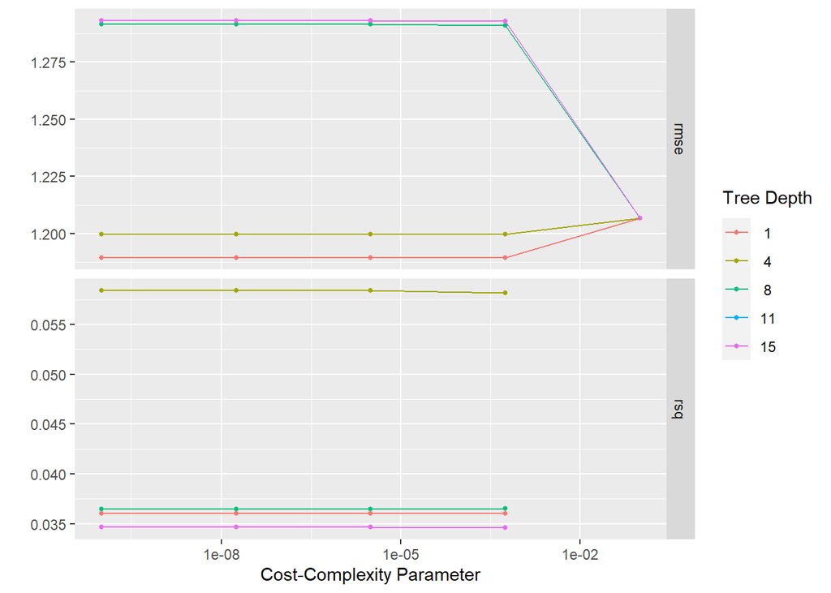

```r
# autoplot tree_res. This will show what happened during the tuning process.
tree_res %>% autoplot()
```

```r
best_tree <- tree_res %>%
  select_best("rmse")

#finalize workflow
final_wf <- tree_wf %>%
  finalize_workflow(best_tree)
final_wf
```

```
## == Workflow ====================================================================
## Preprocessor: Recipe
## Model: decision_tree()
##
## -- Preprocessor ----------------------------------------------------------------
## 1 Recipe Step
##
## * step_dummy()
##
## -- Model -----------------------------------------------------------------------
## Decision Tree Model Specification (regression)
##
## Main Arguments:
##   cost_complexity = 1e-10
##   tree_depth = 1
##
## Computational engine: rpart
```

```r
# final fit - MADA instructions say with training data, but function requires split data
final_fit <-
  final_wf %>%
  last_fit(df_split)

final_fit %>%
  collect_metrics()
```

```
## # A tibble: 2 x 4
##   .metric .estimator .estimate .config
##   <chr>   <chr>          <dbl> <chr>
## 1 rmse    standard    1.19     Preprocessor1_Model1
## 2 rsq     standard    0.000889 Preprocessor1_Model1
```

```r
final_fit %>%
  collect_predictions() %>%
  rmse(BodyTemp, .pred)
```

```
## # A tibble: 1 x 3
##   .metric .estimator .estimate
##   <chr>   <chr>          <dbl>
## 1 rmse    standard        1.19
```

```r
final_tree <- extract_workflow(final_fit)
final_tree
```

```
## == Workflow [trained] ==========================================================
## Preprocessor: Recipe
## Model: decision_tree()
##
## -- Preprocessor ----------------------------------------------------------------
## 1 Recipe Step
##
## * step_dummy()
##
## -- Model -----------------------------------------------------------------------
## n= 508
##
## node), split, n, deviance, yval
##       * denotes terminal node
##
## 1) root 508 742.9363 98.93642
##   2) Sneeze_Yes>=0.5 280 259.6477 98.69107 *
##   3) Sneeze_Yes< 0.5 228 445.7356 99.23772 *
```

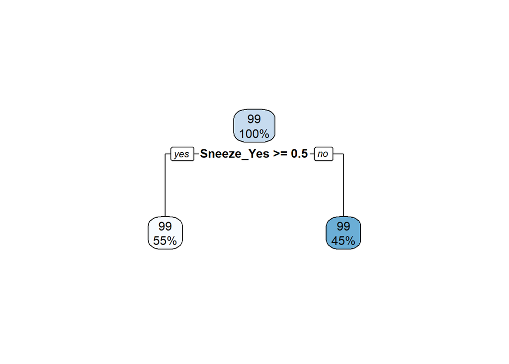

```r
# plot tree with rpart.plot
final_tree %>%
  extract_fit_engine() %>%
  rpart.plot(roundint = FALSE)
```

```r
# LASSO
# continue using same data split and linear regression model
# continue using same bt_train_rec

lasso_wf <-
  workflow() %>%
  add_model(lm_mod) %>%
  add_recipe(bt_train_rec)

lasso_reg_grid <- tibble(penalty = 10^seq(-4, -1, length.out = 30))

lasso_res <- # this will throw a warning saying there are no tuning parameters
  lasso_wf %>%
  tune_grid(folds,
            grid = lasso_reg_grid,
            control = control_grid(save_pred = TRUE),
            metrics = metric_set(rmse))
```

```r
lasso_res %>%
  show_best("rmse")
```

```
## # A tibble: 1 x 6
##   .metric .estimator  mean     n std_err .config
##   <chr>   <chr>      <dbl> <int>   <dbl> <chr>
## 1 rmse    standard    1.18    25  0.0167 Preprocessor1_Model1
```

```r
# select best
lasso_best <- lasso_res %>%
  select_best("rmse")
lasso_best
```

```
## # A tibble: 1 x 1
##   .config
##   <chr>
## 1 Preprocessor1_Model1
```

```r
# finalize workflow
final_lasso_wf <-
  lasso_wf %>%
  finalize_workflow(lasso_best)

# final fit with split data
final_lasso_fit <- final_lasso_wf %>%
  last_fit(df_split)

final_lasso_fit %>%
  collect_metrics()
```

```
## # A tibble: 2 x 4
##   .metric .estimator .estimate .config
##   <chr>   <chr>          <dbl> <chr>
## 1 rmse    standard      1.20   Preprocessor1_Model1
## 2 rsq     standard      0.0231 Preprocessor1_Model1
```

Create random forest using the same data sets and the same cross-validation object.

```r
# Forest
# use same dataset and recipes
# how many cores does my computer have?
cores <- parallel::detectCores()
cores
```

```
## [1] 8
```

Set the model engine. Leaving mtry and min_n eqult to tune() for now. Running the model this way will help evaluate how to tune the model using these parameters.

```r
rf_mod <- rand_forest(mtry = tune(), min_n = tune(), trees = 1000) %>%
  set_engine("ranger", num.threads = cores) %>%
  set_mode("regression")

rf_wf <- workflow() %>%
  add_model(rf_mod) %>%
  add_recipe(bt_train_rec)

rf_mod %>% parameters()
```

```
## Collection of 2 parameters for tuning
##
##  identifier  type    object
##        mtry  mtry nparam[?]
##       min_n min_n nparam[+]
##
## Model parameters needing finalization:
##    # Randomly Selected Predictors ('mtry')
##
## See `?dials::finalize` or `?dials::update.parameters` for more information.
```

```r
rf_res <- rf_wf %>%
  tune_grid(folds,
            grid = 25,
            control = control_grid(save_pred = TRUE),
            metrics = metric_set(rmse))
```

```
## i Creating pre-processing data to finalize unknown parameter: mtry
```

```r
rf_res %>%
  show_best(metric = "rmse")
```

```
## # A tibble: 5 x 8
##    mtry min_n .metric .estimator  mean     n std_err .config
##   <int> <int> <chr>   <chr>      <dbl> <int>   <dbl> <chr>
## 1     4    32 rmse    standard    1.16    25  0.0168 Preprocessor1_Model07
## 2     6    26 rmse    standard    1.16    25  0.0167 Preprocessor1_Model24
## 3     3    22 rmse    standard    1.16    25  0.0168 Preprocessor1_Model25
## 4     6    17 rmse    standard    1.17    25  0.0167 Preprocessor1_Model06
## 5    12    37 rmse    standard    1.17    25  0.0168 Preprocessor1_Model23
```

```r
rf_res %>%
  collect_predictions()
```

```
## # A tibble: 63,500 x 8
##    id      id2   .pred  .row  mtry min_n BodyTemp .config
##    <chr>   <chr> <dbl> <int> <int> <int>    <dbl> <chr>
##  1 Repeat1 Fold1  98.9     9    10    24     97.7 Preprocessor1_Model01
##  2 Repeat1 Fold1  99.1    10    10    24     98.2 Preprocessor1_Model01
##  3 Repeat1 Fold1  98.6    27    10    24     97.4 Preprocessor1_Model01
##  4 Repeat1 Fold1  98.9    31    10    24     97.7 Preprocessor1_Model01
##  5 Repeat1 Fold1  98.9    33    10    24     97.9 Preprocessor1_Model01
##  6 Repeat1 Fold1  98.7    41    10    24     98.2 Preprocessor1_Model01
##  7 Repeat1 Fold1  98.8    46    10    24     98.2 Preprocessor1_Model01
##  8 Repeat1 Fold1  98.9    49    10    24     98.1 Preprocessor1_Model01
##  9 Repeat1 Fold1  99.0    53    10    24     98.1 Preprocessor1_Model01
## 10 Repeat1 Fold1  99.1    64    10    24     98   Preprocessor1_Model01
## # ... with 63,490 more rows
```

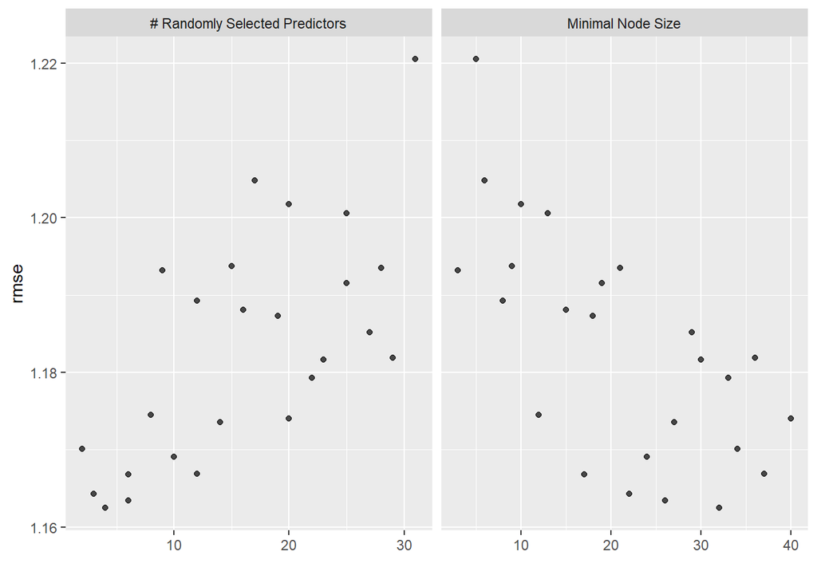

```r
# autoplot to show how the model was tuned
autoplot(rf_res)
```

```r
#select best
rf_best <-
  rf_res %>%
  select_best(metric = "rmse")
rf_best
```

```
## # A tibble: 1 x 3
##    mtry min_n .config
##   <int> <int> <chr>
## 1     4    32 Preprocessor1_Model07
```

```r
#finalize workflow
final_rf_wf <-
  rf_wf %>%
  finalize_workflow(rf_best)

# final fit with split data
final_fit_rf <- final_rf_wf %>%
  last_fit(df_split)

final_fit_rf %>%
  collect_metrics()
```

```
## # A tibble: 2 x 4
##   .metric .estimator .estimate .config
##   <chr>   <chr>          <dbl> <chr>
## 1 rmse    standard      1.17   Preprocessor1_Model1
## 2 rsq     standard      0.0101 Preprocessor1_Model1
```

```r
rf_last_mod <-
  rand_forest(mtry = 6,min_n = 28, trees = 1000) %>%
  set_engine("ranger", num.threads = cores) %>%
  set_mode("regression")

rf_last_wf <-
  final_rf_wf %>%
  update_model(rf_last_mod)

# using split data again (can't specifically use test data)
rf_last_fit <-
  rf_last_wf %>%
  last_fit(df_split)

collect_metrics(rf_last_fit)
```

```
## # A tibble: 2 x 4
##   .metric .estimator .estimate .config
##   <chr>   <chr>          <dbl> <chr>
## 1 rmse    standard     1.18    Preprocessor1_Model1
## 2 rsq     standard     0.00876 Preprocessor1_Model1
```

The RMSE of the random forest model is 1.18, which is still among the best scores of all the models tried. This final test does show that the random forest seems to be the most robust model created, compared to the LASSO and the decision tree.